## Principal Components

We will use `USArrests` data

```r
dimnames(USArrests)
```

```
## [[1]]
##  [1] "Alabama"        "Alaska"         "Arizona"        "Arkansas"
##  [5] "California"     "Colorado"       "Connecticut"    "Delaware"
##  [9] "Florida"        "Georgia"        "Hawaii"         "Idaho"
## [13] "Illinois"       "Indiana"        "Iowa"           "Kansas"
## [17] "Kentucky"       "Louisiana"      "Maine"          "Maryland"
## [21] "Massachusetts"  "Michigan"       "Minnesota"      "Mississippi"
## [25] "Missouri"       "Montana"        "Nebraska"       "Nevada"
## [29] "New Hampshire"  "New Jersey"     "New Mexico"     "New York"
## [33] "North Carolina" "North Dakota"   "Ohio"           "Oklahoma"
## [37] "Oregon"         "Pennsylvania"   "Rhode Island"   "South Carolina"
## [41] "South Dakota"   "Tennessee"      "Texas"          "Utah"
## [45] "Vermont"        "Virginia"       "Washington"     "West Virginia"
## [49] "Wisconsin"      "Wyoming"
##
## [[2]]
## [1] "Murder"   "Assault"  "UrbanPop" "Rape"
```

We will look at the means and variance of variable.

```r
apply(USArrests,2,mean)
```

```
##   Murder  Assault UrbanPop     Rape
##    7.788  170.760   65.540   21.232
```

```r
apply(USArrests,2,var)
```

```
##     Murder    Assault   UrbanPop       Rape
##   18.97047 6945.16571  209.51878   87.72916
```

We see that `Assault` has a much larger variance than other variables so it would dominate the principal components, so there is a need to standardize the variables when we perform PCA.

```r
pca.out = prcomp(USArrests, scale=TRUE)
```

`scale=TRUE` argument makes the variable standardized i.e. `mean =0`, `s.d. =1`

```r
pca.out
```

```
## Standard deviations (1, .., p=4):
## [1] 1.5748783 0.9948694 0.5971291 0.4164494
##
## Rotation (n x k) = (4 x 4):
##                 PC1        PC2        PC3         PC4
## Murder   -0.5358995  0.4181809 -0.3412327  0.64922780
## Assault  -0.5831836  0.1879856 -0.2681484 -0.74340748
## UrbanPop -0.2781909 -0.8728062 -0.3780158  0.13387773
## Rape     -0.5434321 -0.1673186  0.8177779  0.08902432
```

As loadings of first principal component is somewhat equal in all crimes, so it is telling us about the crime rates. While loading of `UrbanPop` in second principal component is highes, so it is telling about urban population.

```r
names(pca.out)
```

```
## [1] "sdev"     "rotation" "center"   "scale"    "x"
```

We can also make a biplot to look a t principal components.

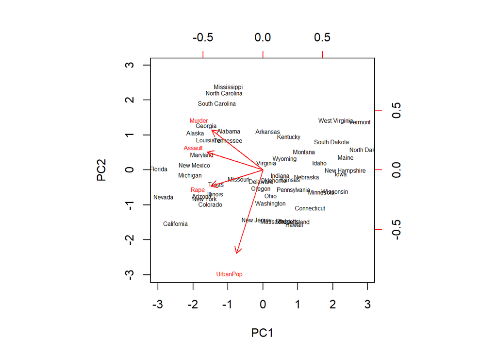

```r
biplot(pca.out, scale= 0, cex= 0.5)
```

First principal component is largely due to murder, assault and rape. As we know computer has negative loadings and negative scores. Negative*negative= positive , so the states in left region has high crime rates and states in right have less crime rates.

In second principal component, the main loading is due to urban population, so vertical axis corresponds to amount of urban population.